```python
%%html
<script>
  function code_toggle() {
    if (code_shown){
      $('div.input').hide('500');
      $('#toggleButton').val('Show Code')
    } else {
      $('div.input').show('500');
      $('#toggleButton').val('Hide Code')
    }
    code_shown = !code_shown
  }

  $( document ).ready(function(){
    code_shown=false;
    $('div.input').hide()
  });
</script>
<form action="javascript:code_toggle()"><input type="submit" id="toggleButton" value="Show Code"></form>
```

# See dependence of s1_80_p_area on time between scatters in double scatter events

```python
import numpy as np
import matplotlib
import matplotlib.pyplot as plt
from scipy.optimize import curve_fit       # curve fitting libraries
import pandas as pd
from matplotlib.colors import LogNorm
from collections import defaultdict
from array import array
import pylab
std = pd.read_csv("scatter_time_diff.csv")
```

```python
td = []
def is_odd(num):
    if (num + 1) % 2 == 0:
        return True
    else:
        return False

for i in range(len(std.time_diff)):
    if is_odd(i):
        td.append(std.time_diff[i])

tds = pd.Series(td,name = "time_diff")
evt = std.event.dropna().astype(int)
```

```python
strd = pd.DataFrame({ 'event_number' : evt,
                    'time_diff' : td })
```

```python
%%capture
import hax
from hax import cuts
hax.init(experiment='XENON1T',
         use_runs_db=False,
         pax_version_policy='loose',
         main_data_paths=['~/data/nrsim/SWdoubleevents'],
         minitree_paths = ['~/data/nrsim/SWdoubleevents/double_event_minitrees'])
```

```python
%%capture
df = hax.minitrees.load("SWdoubleevents",["Fundamentals",'Basics','Extended','TotalProperties'])
```

```python
df_s2 = df.merge(strd,on="event_number")
df_s2 = df_s2.dropna()
```

I have simulated data and take the time difference between the events in the double scatter from the input csv. I want to produce a clearer picture of the s1 waveform shape as a function of time between scatters of a double scatter events from simulated data. Seen in "Double Scatters in AmBe" of Erik Hogenbirk's. I apply all the cuts provided by Fei.

```python
# Tianyu's single scatter S2 cut

def other_s2_bound(s2_area):
        rescaled_s2_0 = s2_area * 0.00832 + 72.3
        rescaled_s2_1 = s2_area * 0.03 - 109

        another_term_0 = 1 / (np.exp((s2_area - 23300) * 5.91e-4) + 1)
        another_term_1 = 1 / (np.exp((23300 - s2_area) * 5.91e-4) + 1)

        return rescaled_s2_0 * another_term_0 + rescaled_s2_1 * another_term_1

#def other_s2_bound(x):
#    return x * 0.00832 + 72.3

# S2 AFT cut, provided by Adam
def s2aft_bot(s2size):
    return 0.6648160611018054 - 2.590402853814859e-7 * s2size - 0.8531029789184852 / np.log(s2size)

def s2aft_top(s2size):
    return 0.6177399420527526 + 3.713166211522462e-8 * s2size + 0.5460484265254656 / np.log(s2size)

### S2 minimum width cut assuming a Z of -13.45.
z_max=-9
z_min=-92.9


## S2 width cut based on Diffusion model, provided by Yuehuan
def s2width_threshold_low(s2size=100,z=z_max):
    diff_mode_tune=np.sqrt(121522 - 30791.2*z)
#    return (-0.3 + 0.3*np.log10(s2size))*diff_mode_tune * (s2size<7e3) + (s2size>=7e3)*8.53529412004276899e-01*diff_mode_tune
    return ((s2size < 2500)*(-0.9 + 0.5*np.log10(s2size)) + (s2size > 2500)*7.98970004336018724e-01)*diff_mode_tune

def s2width_threshold_up(s2size=100,z=z_min):
    diff_mode_tune=np.sqrt(121522 - 30791.2*z)
#    return (2.3 - 0.3*np.log10(s2size))*diff_mode_tune * (s2size<7e3) + (s2size>=7e3)*1.14647058799572288*diff_mode_tune
    return ((s2size < 4500)*(3 - 0.5*np.log10(s2size)) + (s2size>4500)*1.17339374311232825e+00)*diff_mode_tune

def erband_low(cs1=10):
    return (np.exp(-0.745260+(-0.030989)*cs1)+ 1.855258 + (-6.770003e-04)*cs1)+np.log10(cs1)

def erband_up(cs1=10):
    return np.exp(-0.134897+(-0.051300)*cs1)+ 2.342610 + (-1.088547e-03)*cs1+np.log10(cs1)

from scipy import interpolate
unblind_bound = interpolate.interp1d(
    [0, 10, 20,
     30, 40, 50,
     60, 70, 200,300],
    [200, 250, 400,
     1000, 1500, 1500,
     2000, 2000,2000,2000],
)

nr_median = {'pid': np.poly1d( [1.9846795358916394e-09, -8.9960948861885862e-07, 0.00014845814391104396, -0.012869279612389997, 2.2566980076386964] ),
             'pidbottom' : np.poly1d( [2.043947952100446e-09, -9.2634141775575512e-07, 0.00015175759051522079, -0.012991863588418901, 1.8206807429394156] )
            }

nr_95 = {'pid' : np.poly1d( [-2.9166458074656073e-11, 1.470169127820138e-08, -2.7684612569188748e-06, 0.00024507839732739513, -0.012098969366058176, 1.9450229233778022] ),
        'pidbottom' : np.poly1d( [-3.6445795328845042e-11, 1.8824918011275691e-08, -3.5948810050628432e-06, 0.00031555965062656963, -0.014484541097406578, 1.5290305282532244])}

def GetNewPlot(xtitle,ytitle):
    fig = plt.figure()
    fig.set_figheight(5)
    fig.set_figwidth(8)
    ax = fig.add_subplot(111)
    plt.tight_layout()
    plt.ylabel(ytitle, fontsize=18)
    plt.xlabel(xtitle, fontsize=18)
    return fig, ax
```

```python
import pax
from pax import configuration, units
PAX_CONFIG = configuration.load_configuration('XENON1T')
diffusion_constant = PAX_CONFIG['WaveformSimulator']['diffusion_constant_liquid']
v_drift = PAX_CONFIG['DEFAULT']['drift_velocity_liquid']

def s2_width_model(z):
    w0 = 348.6 * units.ns
    return np.sqrt(w0 ** 2 - 4.0325 * diffusion_constant * z / v_drift ** 3)

df_s2['relative_width'] = df_s2['s2_range_50p_area'] / s2_width_model(df_s2['z'])


## upper s2 width
def S2WidthHigh(s2=200):
    return 3 - 0.5*np.log10(s2) if s2 < 2500 else 3 - 0.5*np.log10(2500)

def S2WidthLow(s2=200):
    return -0.9 + 0.5*np.log10(s2) if s2 < 2500 else -0.9 + 0.5*np.log10(2500)


# S2 single cut
def other_s2_bound(x):
    return x * 0.00832 + 72.3

# S2 AFT cut, provided by Adam
def s2aft_bot(s2size):
    return 0.6648160611018054 - 2.590402853814859e-7 * s2size - 0.8531029789184852 / np.log(s2size)

def s2aft_top(s2size):
    return 0.6177399420527526 + 3.713166211522462e-8 * s2size + 0.5460484265254656 / np.log(s2size)
```

```python
%%capture
import lax; print('Using lax version', lax.__version__)
from lax.lichens import sciencerun0

cut = sciencerun0.LowEnergyBackground()
#cut = sciencerun0.SingleElectronS2s()

fiducial = 'normal'
fiducial_options = {'big' : 'CutFiducialFourLeafClover1250kg',
                    'normal' : 'CutFiducialCylinder1T'}

cut.lichen_list.pop(6)
cut.lichen_list.pop(6)
cut.lichen_list.pop(8)

for i, each in enumerate(cut.lichen_list):
    print(i, each.__class__.__name__, 'v%s' % each.version)
```

```python
df_s2 = cut.process(df_s2)
cut_list=cut.get_cut_names()
```

```python
df_lax = df_s2[df_s2.s1_range_50p_area < 800]

for cut_name in cut_list:
    if (cut_name!='CutS2SingleScatterSimple'):
        df_lax = cuts.selection(df_lax, df_lax[cut_name], desc=cut_name)
```

```
CutFiducialCylinder1T selection: 184 rows removed (87.20% passed)
CutS1LowEnergyRange selection: 0 rows removed (100.00% passed)
CutS2Threshold selection: 0 rows removed (100.00% passed)
CutInteractionPeaksBiggest selection: 0 rows removed (100.00% passed)
CutS2AreaFractionTop selection: 25 rows removed (98.01% passed)
CutS1AreaFractionTop selection: 7 rows removed (99.43% passed)
CutS2PatternLikelihood selection: 4 rows removed (99.67% passed)
CutS1PatternLikelihood selection: 4 rows removed (99.67% passed)
CutS2Width selection: 14 rows removed (98.85% passed)
CutS1MaxPMT selection: 1 rows removed (99.92% passed)
CutSingleElectronS2s selection: 3 rows removed (99.75% passed)
CutPreS2Junk selection: 150 rows removed (87.46% passed)
```

```python
xedges = np.linspace(0,60,30)
yedges = np.linspace(100,240,40)
```

```python
H, xedges, yedges = np.histogram2d(df_lax.time_diff,df_lax.s1_range_80p_area,bins = [xedges,yedges])
H = H.T
```

```python
meds = []
means = []
sigs = []
ts = []

for i in range(0,len(xedges) - 1):
    d = df_lax[(df_lax.time_diff < xedges[i+1]) & (df_lax.time_diff > xedges[i])]

    means.append(np.mean(d.s1_range_80p_area))
    meds.append(np.median(d.s1_range_80p_area))
    sigs.append(np.std(d.s1_range_80p_area))
    ts.append(np.mean(d.time_diff))
```

```python
v = np.array(meds)
w = np.array(sigs)

medsmin = list(v - w)
medsmax = list(v + w)
```

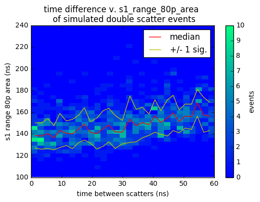

```python
plt.imshow(H, aspect = 'auto', interpolation = 'nearest', cmap = 'winter', origin='low', extent=[xedges[0], xedges[-1], yedges[0], yedges[-1]])
plt.xlabel("time between scatters (ns)")
plt.ylabel("s1 range 80p area (ns)")
plt.title("time difference v. s1_range_80p_area \n of simulated double scatter events")
plt.plot(ts,meds,color = 'r')
plt.plot(ts,medsmax,color = 'y')
plt.plot(ts,medsmin,color = 'y')
plt.legend(['median','+/- 1 sig.'])

plt.colorbar(label = "events")

plt.show()
```

## What to see

See an increase in s1_80_p_area as time between two NR identical scatters in the same event increases. Mean increases by a rough 12% from 0 ns to 60ns separation. This makes sense, as the two scatters in the same event should produce resolvable s1s. But, when I look at the simulated waveforms, the shapes of the s1s look very similar! Why are there not two distinct peaks of the same size when I have two identical NR events separated by a time resolvable by the detector?